# Welcome_To_Colab

```python
days_in_year = 365
```

```python
seconds_in_a_day = 24 * 60 * 60
seconds_in_a_day
```

```
86400
```

```python
seconds_in_a_week = 7 * seconds_in_a_day
seconds_in_a_week
```

```
604800
```

```python
seconds_in_a_year = days_in_year * seconds_in_a_day
seconds_in_a_year
```

```
31536000
```

# Task II

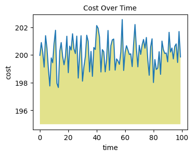

```python
import numpy as np
import IPython.display as display
from matplotlib import pyplot as plt
import io
import base64

ys = 200 + np.random.randn(100)
x = [x for x in range(len(ys))]

fig = plt.figure(figsize=(4, 3), facecolor='w')
plt.plot(x, ys, '-')
plt.fill_between(x, ys, 195, where=(ys > 195), facecolor='y', alpha=0.45)
plt.title("Cost Over Time", fontsize=10)
plt.xlabel( "time" )
plt.ylabel("cost")

data = io.BytesIO()
plt.savefig(data)
image = F"data:…)).decode()}"
alt = "Sample Visualization"
#display.display(display.Markdown(F"""![{alt}]({image})"""))
plt.show()
plt.close(fig)
```

# Task III

Changes to the graph and why they're important:

- I changed the title Sample Visualization to Cost Over Time by changing plt.title("Sample Visualization", fontsize=10) to plt.title("Cost Over Time", fontsize=10). I added axis labels Cost and Time by using the plt.xlabel and plt.ylabel methods. Labels are important so decision makers can easily understand the meaning of the graph at a glance.
- In the code for the graph above, facecolor = 'g' has been changed to facecolor = 'y', changing the color of the graph from green to yellow. I changed the alpha argument in the parameters for plt.fill_between from .6 to .45. After some experimentation, I believe the alpha controls the opacity of the fill color.
- I commented out the display.display expression and added the plt.show() instead. The .show method is easier to write and easier for other programmers to read.

# Task IV

```python
import pandas as pd

a1_data = pd.read_csv('https://raw.githubusercontent.com/matthewpecsok/4482_fall_2024/main/data/assignment_1.csv')
a1_data.tail(8)
```

|  | customer_id | sale_amount | category |
| --- | --- | --- | --- |
| 0 | 4.0 | 5345.23 | A |
| 1 | 3.0 | 534.65 | B |
| 2 | 5.0 | 456.87 | A |
| 3 | 6.0 | 987.99 | NaN |
| 4 | NaN | 53.14 | A |
| 5 | 1.0 | 2325.23 | NaN |
| 6 | 9.0 | 7657.65 | A |
| 7 | 10.0 | NaN | C |

# Task V

```python
a1_data.shape
```

```
(8, 3)
```

```python
a1_data.info()
```

```
<class 'pandas.core.frame.DataFrame'>
RangeIndex: 8 entries, 0 to 7
Data columns (total 3 columns):
 #   Column       Non-Null Count  Dtype
---  ------       --------------  -----
 0   customer_id  7 non-null      float64
 1   sale_amount  7 non-null      float64
 2   category     6 non-null      object
dtypes: float64(2), object(1)
memory usage: 324.0+ bytes
```

There are 2 float columns and 1 string column. There are 4 null values, all columns have at least 1 null value. Null values represent a missing or empty cell. They are important because they could be a recording error or something else, and they can affect statistical analysis and lead to incorrect insights.

# Task VI

```python
hello_world = "Hello World"
print(hello_world)
```

```
Hello World
```

```python
fruit = ["apple", "tomato", "watermelon"]
print(fruit[1])
```

```
tomato
```